# ST 503 Hw 6

Robin Baldeo

November 23, 2018

# Question 1 (Exercise 2.2)

#### (A)

```r
q1<- glm(Class~., data = wbca, family=binomial)
q1.s<- summary(q1)

q1.s
```

```
##
## Call:
## glm(formula = Class ~ ., family = binomial, data = wbca)
##
## Deviance Residuals:
##      Min        1Q    Median        3Q       Max
## -2.48282  -0.01179   0.04739   0.09678   3.06425
##
## Coefficients:
##             Estimate Std. Error z value Pr(>|z|)
## (Intercept) 11.16678    1.41491   7.892 2.97e-15 ***
## Adhes       -0.39681    0.13384  -2.965  0.00303 **
## BNucl       -0.41478    0.10230  -4.055 5.02e-05 ***
## Chrom       -0.56456    0.18728  -3.014  0.00257 **
## Epith       -0.06440    0.16595  -0.388  0.69795
## Mitos       -0.65713    0.36764  -1.787  0.07387 .
## NNucl       -0.28659    0.12620  -2.271  0.02315 *
## Thick       -0.62675    0.15890  -3.944 8.01e-05 ***
## UShap       -0.28011    0.25235  -1.110  0.26699
## USize        0.05718    0.23271   0.246  0.80589
## ---
## Signif. codes:  0 '***' 0.001 '**' 0.01 '*' 0.05 '.' 0.1 ' ' 1
##
## (Dispersion parameter for binomial family taken to be 1)
##
##     Null deviance: 881.388  on 680  degrees of freedom
## Residual deviance:  89.464  on 671  degrees of freedom
## AIC: 109.46
##
## Number of Fisher Scoring iterations: 8
```

```r
#deviance
dev<- q1.s$deviance

#degree of freedom
df<- q1.s$df[2]

#determine the fit
pchisq(dev,df, lower.tail = F)
```

```
## [1] 1
```

Using just the deviance 89.464195 and the residual degree of freedom 671 is not enough to determine the fit we must find the p-value from the chi square distribution. Since the p-value is greater than .05 we fail to reject the null and conclude that the binominal is a satisfactory fit.

#### (B)

```r
q2<- step(q1, direction = "backward")
```

```
## Start:  AIC=109.46
## Class ~ Adhes + BNucl + Chrom + Epith + Mitos + NNucl + Thick +
##     UShap + USize
##
##         Df Deviance    AIC
## - USize  1   89.523 107.52
## - Epith  1   89.613 107.61
## - UShap  1   90.627 108.63
## <none>       89.464 109.46
## - Mitos  1   93.551 111.55
## - NNucl  1   95.204 113.20
## - Adhes  1   98.844 116.84
## - Chrom  1   99.841 117.84
## - BNucl  1  109.000 127.00
## - Thick  1  110.239 128.24
##
## Step:  AIC=107.52
## Class ~ Adhes + BNucl + Chrom + Epith + Mitos + NNucl + Thick +
##     UShap
##
##         Df Deviance    AIC
## - Epith  1   89.662 105.66
## - UShap  1   91.355 107.36
## <none>       89.523 107.52
## - Mitos  1   93.552 109.55
## - NNucl  1   95.231 111.23
## - Adhes  1   99.042 115.04
## - Chrom  1  100.153 116.15
## - BNucl  1  109.064 125.06
## - Thick  1  110.465 126.47
##
## Step:  AIC=105.66
## Class ~ Adhes + BNucl + Chrom + Mitos + NNucl + Thick + UShap
##
##         Df Deviance    AIC
## <none>       89.662 105.66
## - UShap  1   91.884 105.88
## - Mitos  1   93.714 107.71
## - NNucl  1   95.853 109.85
## - Adhes  1  100.126 114.13
## - Chrom  1  100.844 114.84
## - BNucl  1  109.762 123.76
## - Thick  1  110.632 124.63
```

```r
q2.s<- summary(q2)

# the best model with the lowest aic is
q2.s$call
```

```
## glm(formula = Class ~ Adhes + BNucl + Chrom + Mitos + NNucl +
##     Thick + UShap, family = binomial, data = wbca)
```

The best model with the lowest AIC is with `class` as response and `Adhes`, `BNucl` , `Chrom` , `Mitos` ,`NNucl`, `Thick` ,and `UShap` as predictors.

#### (C)

```r
# using the parameters from question 1
#prediction
pi<- t(as.matrix(q2$coefficients))%*%as.matrix(c(1,1, 1, 3, 1, 1, 4, 1), nrow= 1)
pi
```

```
##          [,1]
## [1,] 4.834428
```

```r
#confidience interval
#using the values from question for prediction
x0<- as.matrix(c(1,1, 1, 3, 1, 1, 4, 1), nrow= 1)

oo<- eval(q2.s$call)

eta.hat <- sum(x0 * oo$coefficients)
p.hat <- ilogit(eta.hat); p.hat
```

```
## [1] 0.9921115
```

```r
Sigma <- (summary(oo))$cov.unscaled

#calucating the se
se <- sqrt( t(x0) %*% Sigma %*% x0 )

#getting the 95% for the prediction
ci<- ilogit(c(eta.hat - 1.96 * se, eta.hat + 1.96 * se))
```

The Ci is (0.9757467, 0.9974629).

#### (D)

```r
#function to do comparison
com<- function(o,p){
  v<- as.numeric(rep(0, length(o)))
  for(i in 1:length(o)){
    for(j in 1:length(p)){
      if(o[i] == p[j]){
        v[i]= 0
        break;
      }else{
        v[i]= 1
      }
    }
  }
  return(sum(v))
}

# malignant
pre.m<- which(oo$fitted.values<.5)
or.m<- which(wbca$Class==0)

mi<- com(o= or.m, p = pre.m)

#11 misclassied

#benign
pre.b<- which(oo$fitted.values>.5)
or.b<- which(wbca$Class==1)

be<- com(o= or.b, p = pre.b)

#9 misclassfied
```

With malignant there were 11 and with the benign , there were 9 that were misclassified.

#### (E)

```r
pre.m<- which(oo$fitted.values<.9)
or.m<- which(wbca$Class==0)

mi<- com(o= or.m, p = pre.m)

#1 misclassied

#benign .9
pre.b<- which(oo$fitted.values>.9)
or.b<- which(wbca$Class==1)

be<- com(o= or.b, p = pre.b)

#16 misclassfied
```

With Malignant there were 1 and with the benign there were 16 that were misclassified. Looking a the .5 cut off and the .9 cut off, I think it is difficult to determine an ideal cut off number. We get very different results with these cut off numbers and choosing the incorrect cut off would results in incorrect classification.

#### (F)

```r
#getting the every 3rd index
r<- as.numeric(rep(0, nrow(wbca)))
o<- as.numeric(rep(0, nrow(wbca)))
for(i in 1:nrow(wbca)){
  if(i%%3 == 0){
    r[i]= i
  }else{
    o[i]= i
  }
}
#filter out the 0
r<- r[r>0]
o<- o[o>0]

test<- wbca[r,,drop= FALSE]

train<- wbca[o,,drop= FALSE]


#using training to determine best model with lowest aic

tr<- glm(Class~., data = train, family=binomial)
summary(tr)
```

```
##
## Call:
## glm(formula = Class ~ ., family = binomial, data = train)
##
## Deviance Residuals:
##      Min        1Q    Median        3Q       Max
## -1.98138  -0.00954   0.03310   0.07084   3.07275
##
## Coefficients:
##             Estimate Std. Error z value Pr(>|z|)
## (Intercept)  12.0244     2.0462   5.876 4.19e-09 ***
## Adhes        -0.4859     0.1555  -3.126  0.00177 **
## BNucl        -0.3732     0.1292  -2.888  0.00388 **
## Chrom        -0.6655     0.2536  -2.625  0.00868 **
## Epith         0.1779     0.2148   0.828  0.40744
## Mitos        -0.6075     0.5103  -1.190  0.23388
## NNucl        -0.5168     0.1828  -2.828  0.00469 **
## Thick        -0.6533     0.2044  -3.197  0.00139 **
## UShap        -0.5291     0.2612  -2.026  0.04280 *
## USize         0.2672     0.2320   1.152  0.24947
## ---
## Signif. codes:  0 '***' 0.001 '**' 0.01 '*' 0.05 '.' 0.1 ' ' 1
##
## (Dispersion parameter for binomial family taken to be 1)
##
##     Null deviance: 592.796  on 453  degrees of freedom
## Residual deviance:  57.651  on 444  degrees of freedom
## AIC: 77.651
##
## Number of Fisher Scoring iterations: 9
```

```r
tr.1<- step(tr, direction = "backward")
```

```
## Start:  AIC=77.65
## Class ~ Adhes + BNucl + Chrom + Epith + Mitos + NNucl + Thick +
##     UShap + USize
##
##         Df Deviance    AIC
## - Epith  1   58.340 76.340
## - USize  1   58.880 76.880
## <none>       57.651 77.651
## - Mitos  1   60.712 78.712
## - UShap  1   61.450 79.450
## - Chrom  1   65.983 83.983
## - BNucl  1   67.373 85.373
## - NNucl  1   67.538 85.538
## - Adhes  1   68.073 86.073
## - Thick  1   71.162 89.162
##
## Step:  AIC=76.34
## Class ~ Adhes + BNucl + Chrom + Mitos + NNucl + Thick + UShap +
##     USize
##
##         Df Deviance    AIC
## - USize  1   59.536 75.536
## <none>       58.340 76.340
## - Mitos  1   61.264 77.264
## - UShap  1   61.702 77.702
## - Chrom  1   66.515 82.515
## - BNucl  1   67.402 83.402
## - NNucl  1   67.556 83.556
## - Adhes  1   68.310 84.310
## - Thick  1   72.311 88.311
##
## Step:  AIC=75.54
## Class ~ Adhes + BNucl + Chrom + Mitos + NNucl + Thick + UShap
##
##         Df Deviance    AIC
## <none>       59.536 75.536
## - UShap  1   61.894 75.894
## - Mitos  1   62.329 76.329
## - Chrom  1   66.762 80.762
## - NNucl  1   67.576 81.576
## - BNucl  1   68.332 82.332
## - Adhes  1   68.359 82.359
## - Thick  1   72.363 86.363
```

```r
tr.2<- summary(tr.1)

# the best model with the lowest aic is
tr_r<- eval(tr.2$call, tr)

#comparing models
re<- anova(tr_r, tr)

pchisq(re$Deviance[2],re$Df[2])
```

```
## [1] 0.6103852
```

```r
#since we have a large p-value greater than alpha then the simpler model is prefered.

#using the test data to the precistion like in part c
#using the values from question for prediction

oo<- glm(Class ~ Adhes + BNucl + Chrom + Mitos + NNucl +   Thick + UShap, family = binomial, data = test)

eta.hat <- sum(x0 * oo$coefficients)
p.hat2 <- ilogit(eta.hat);
p.hat2
```

```
## [1] 0.9970556
```

Here we see the model is identical to the reduced model from part c using the `train` data. Now we also see that the prediction value using parameters from question 1 (used in part c) 0.9921115 is near identical to the prediction using the `test` data where prediction is 0.9970556 using the same parameters. Therefore, the process of splitting the data into two parts yields almost the same prediction as part c.

# Question 2 (Exercise 3.1)

```r
#block the data into groups of 5 X 20 matrix
m<- matrix(discoveries,  ncol  =  20)

#variable to hold the sum of the blocks
rate<- apply(m, 2, sum)
block<- apply(m, 2, length)
year<- seq(1:20)

mod_p1<- glm(rate~  year , family= poisson)
summary(mod_p1)
```

```
##
## Call:
## glm(formula = rate ~ year, family = poisson)
##
## Deviance Residuals:
##     Min       1Q   Median       3Q      Max
## -3.0956  -0.9789  -0.2236   0.7763   3.9335
##
## Coefficients:
##              Estimate Std. Error z value Pr(>|z|)
## (Intercept)  3.005667   0.111113  27.050  < 2e-16 ***
## year        -0.026316   0.009918  -2.653  0.00797 **
## ---
## Signif. codes:  0 '***' 0.001 '**' 0.01 '*' 0.05 '.' 0.1 ' ' 1
##
## (Dispersion parameter for poisson family taken to be 1)
##
##     Null deviance: 60.714  on 19  degrees of freedom
## Residual deviance: 53.625  on 18  degrees of freedom
## AIC: 147.25
##
## Number of Fisher Scoring iterations: 4
```

```r
mod_p2<- glm(rate~ offset(log(block))+ year , family= poisson)
summary(mod_p2)
```

```
##
## Call:
## glm(formula = rate ~ offset(log(block)) + year, family = poisson)
##
## Deviance Residuals:
##     Min       1Q   Median       3Q      Max
## -3.0956  -0.9789  -0.2236   0.7763   3.9335
##
## Coefficients:
##              Estimate Std. Error z value Pr(>|z|)
## (Intercept)  1.396229   0.111113  12.566  < 2e-16 ***
## year        -0.026316   0.009918  -2.653  0.00797 **
## ---
## Signif. codes:  0 '***' 0.001 '**' 0.01 '*' 0.05 '.' 0.1 ' ' 1
##
## (Dispersion parameter for poisson family taken to be 1)
##
##     Null deviance: 60.714  on 19  degrees of freedom
## Residual deviance: 53.625  on 18  degrees of freedom
## AIC: 147.25
##
## Number of Fisher Scoring iterations: 4
```

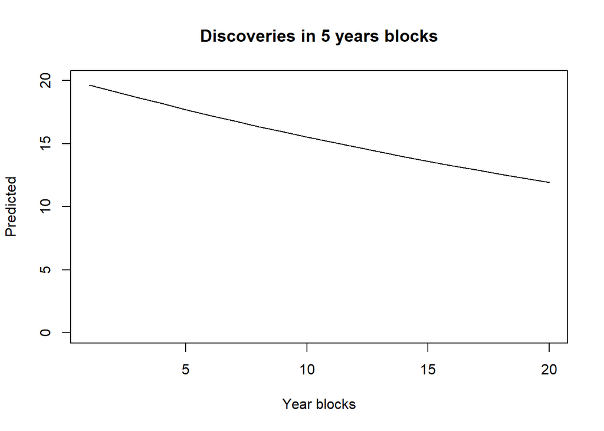

```r
plot(mod_p2$fitted.values , ylim = c(0, 20), type= "l", ylab = "Predicted", xlab="Year blocks", main = "Discoveries in 5 years blocks")
```

```r
#From the plot the rate of discoveries appears to be on the decrease over the years instead of constant.
```

From the plot the rate of discoveries appears to be on the decrease over the years instead of constant.

# Question 3

#### (A)

```r
x <- seq(-5, 5, length=10)
y <- as.numeric(x > 0)

plot(x,y)
mod<- glm(y~x-1, family = binomial)

summary(mod)
```

```
##
## Call:
## glm(formula = y ~ x - 1, family = binomial)
##
## Deviance Residuals:
##        Min          1Q      Median          3Q         Max
## -1.983e-05  -2.110e-08   0.000e+00   2.110e-08   1.983e-05
##
## Coefficients:
##   Estimate Std. Error z value Pr(>|z|)
## x    40.23   55054.91   0.001    0.999
##
## (Dispersion parameter for binomial family taken to be 1)
##
##     Null deviance: 1.3863e+01  on 10  degrees of freedom
## Residual deviance: 7.8648e-10  on  9  degrees of freedom
## AIC: 2
##
## Number of Fisher Scoring iterations: 25
```

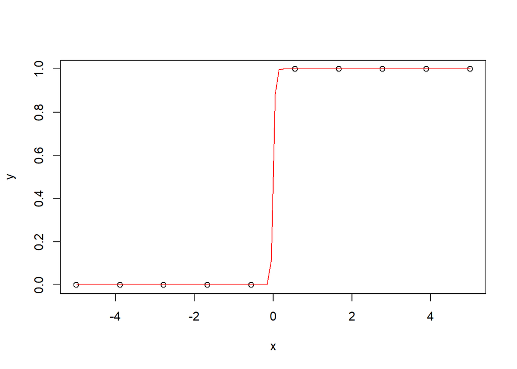

```r
xx <- seq(-5, 5, len=100)
lines(xx, ilogit(mod$coefficients[1]  * xx), col=2)
```

```r
#ci for B
confint(mod)
```

```
##     2.5 %    97.5 %
## -4205.399        NA
```

Based on the CI, we can see the breakdown of the MLE. The MLE fails and we cannot utilize the Wald test , therefore we have a lower bound and no upper bound.

#### (B)

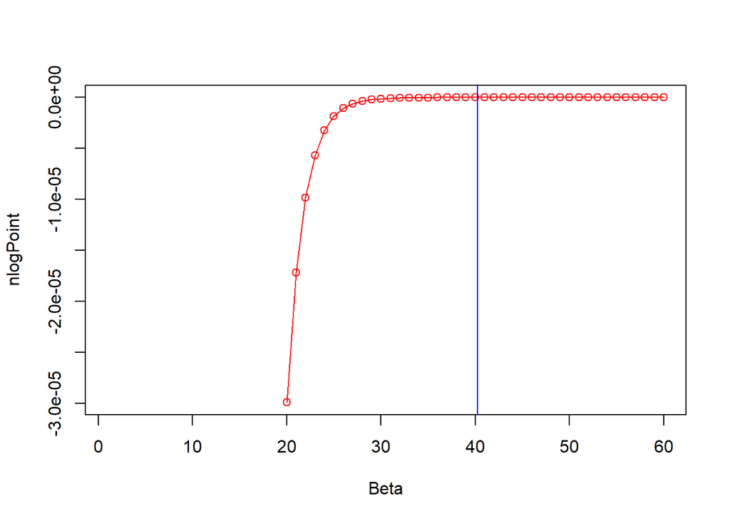

```r
loglik <- function(theta) {

  # a <- theta[1]
  b <- theta[1]
  #using the logit formula
  p <- sapply(x, function(p){(exp(1)^(b*p))/(1+ exp(1)^(b*p))})
  o <- sum(dbinom(y, size=1, prob=p, log=TRUE))
  return(o)

}

nlogPoint<- as.double()
for( i in 20:60){
  nlogPoint[i]<- loglik(i)
}

plot(nlogPoint, xlab  = "Beta", col = "red", type = "o")

#vertical line of b-hat
abline(v=mod$coefficients[1], col = "blue")
```

Above we see separation from the plot where the plot fits perfectly. This is also evident with the extremely large standard error. Indicating our estimate is junk.

#### (C)

The plot show our function bound by 0 and does not meet a maximum but instead stays constant. I think that is the reason why the standard error is so large.

# Question 4

#### (A)

Given $E(V)= k\alpha$ and $Var(V)= k\alpha^2$ which follows a Gamma distrubtion. Also, given is $E(U|V) = v$ with $Var(U|V)= v$ which follows a poisson distrubtion. Therefore using the law of total expectation:
$$E(U)= E(E(U|V))$$
$$=E(V)$$
$$=k\alpha$$
Using the law of total varaince:
$$Var(U)= E(Var(U|V))+ Var(E(U|V))$$
$$= E(V) + Var(v)$$
$$=k\alpha + k\alpha^2$$
proven.

#### (B)

The negative binominal is more flexible because the variance of the poisson and the mean of the poisson distribution are the same leaving less room for flexibility and resulting in overdispersion. As a result from the summary output. However, with the negative binominal distribution the mean and the variance is different.

#### (C)

```r
#using model from test book page 64
modp <- glm(Species ~ .,family=poisson, gala)

summary(modp)
```

```
##
## Call:
## glm(formula = Species ~ ., family = poisson, data = gala)
##
## Deviance Residuals:
##     Min       1Q   Median       3Q      Max
## -4.9919  -2.9305  -0.4296   1.3254   7.4735
##
## Coefficients:
##               Estimate Std. Error z value Pr(>|z|)
## (Intercept)  2.828e+00  5.958e-02  47.471  < 2e-16 ***
## Endemics     3.388e-02  1.741e-03  19.459  < 2e-16 ***
## Area        -1.067e-04  3.741e-05  -2.853  0.00433 **
## Elevation    2.638e-04  1.934e-04   1.364  0.17264
## Nearest      1.048e-02  1.611e-03   6.502 7.91e-11 ***
## Scruz       -6.835e-04  5.802e-04  -1.178  0.23877
## Adjacent     4.539e-05  4.800e-05   0.946  0.34437
## ---
## Signif. codes:  0 '***' 0.001 '**' 0.01 '*' 0.05 '.' 0.1 ' ' 1
##
## (Dispersion parameter for poisson family taken to be 1)
##
##     Null deviance: 3510.73  on 29  degrees of freedom
## Residual deviance:  313.36  on 23  degrees of freedom
## AIC: 488.19
##
## Number of Fisher Scoring iterations: 5
```

```r
plot(residuals(modp, type="pearson"))

#negative binominal model
modnb<- glm(Species ~ .,negative.binomial(1), gala)

summary(modnb)
```

```
##
## Call:
## glm(formula = Species ~ ., family = negative.binomial(1), data = gala)
##
## Deviance Residuals:
##     Min       1Q   Median       3Q      Max
## -1.3586  -0.5199  -0.1031   0.2427   1.0144
##
## Coefficients:
##               Estimate Std. Error t value Pr(>|t|)
## (Intercept)  2.479e+00  2.205e-01  11.240 8.07e-11 ***
## Endemics     4.901e-02  1.111e-02   4.410 0.000203 ***
## Area        -2.553e-04  2.620e-04  -0.974 0.340038
## Elevation    4.206e-06  1.100e-03   0.004 0.996983
## Nearest      6.177e-03  1.154e-02   0.535 0.597458
## Scruz       -5.246e-04  2.462e-03  -0.213 0.833175
## Adjacent     9.218e-05  2.746e-04   0.336 0.740096
## ---
## Signif. codes:  0 '***' 0.001 '**' 0.01 '*' 0.05 '.' 0.1 ' ' 1
##
## (Dispersion parameter for Negative Binomial(1) family taken to be 0.4360555)
##
##     Null deviance: 54.069  on 29  degrees of freedom
## Residual deviance: 12.901  on 23  degrees of freedom
## AIC: 299.91
##
## Number of Fisher Scoring iterations: 9
```

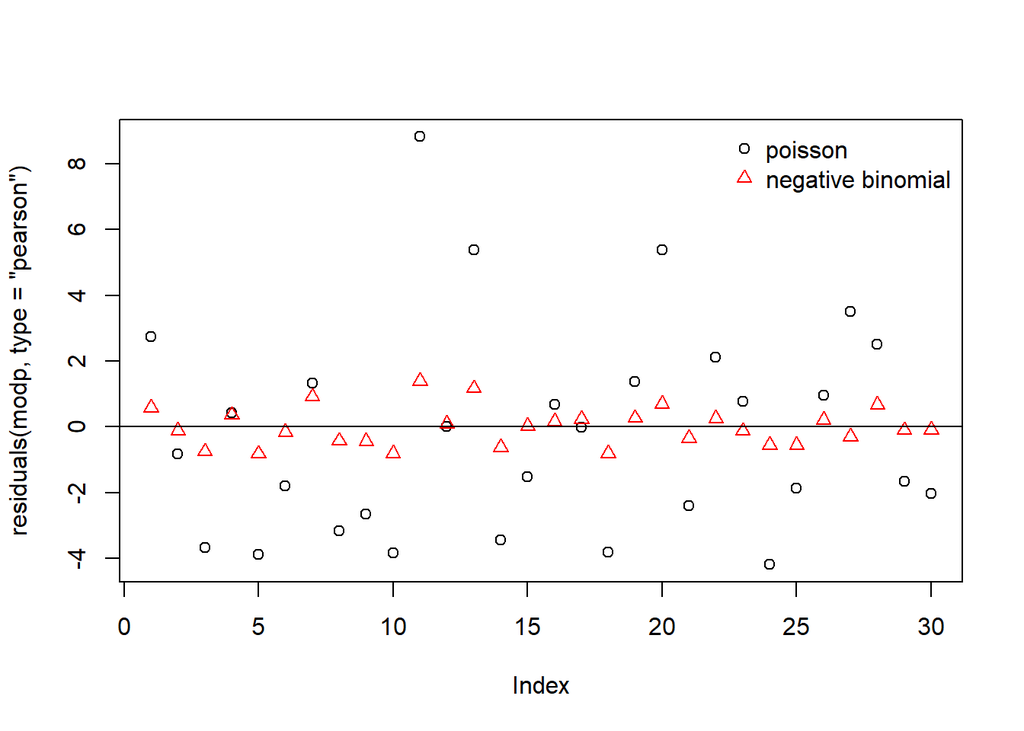

```r
legend("topright", legend = c("poisson","negative binomial"),col=c("black", "red"), pch = c(1,2), bty = "n")
points(residuals(modnb, type="pearson"), col = 2, pch = 2)

abline(h= 0)
```

As show in the plot the using the poisson family in the glm(black), we see that the variance is much larger as shown where the points are more spread out from zero. This is different in regards to the negative binominal where the residuals are more clustered around 0.